# Calculating the Potential for Conflict Index

- The Potential for Conflict Index describes the ammount of agreement or disagreement on flow preferenc among survey respondants.
- Larger PCI scores indicate more disagreement. Smaller PCI scores indicate less disagreement (more agreement)
- For example a PCI score of 1 indicates that respondents are evenly split into two polar-opposit camps (e.g unfavorable v. favorable)
- On the other hand a PCI score of 0 indicates complete consensus among respondents
- This notebook breaks down how PCI is calculated in `flow-pref-analysis.R`

## Step 1: Import tidy survey response data

- Tidy survey response data exported from `tidy-response-data.R` as .Rdata files
- One file contains respondent attribute data
- Another file contains flow preference data

```r
load(file = here::here("flow_pref","survey-analysis","respondend-attributes.Rdata"))
load(file = here::here("flow_pref","survey-analysis","flow-pref-data.Rdata"))
```

## Step 2: Calculate average preference and PCI

- Calculate average preference score for each flow bin
- PCI is observed sum of the preference score distance vector, divided by the theoretical maxumum sum of the distance vector
- the `dist` command is used to calculate a distance matrix, quantifying the distance between each pair of preference scores in each flow bin

```r
segment_name = "Filter Plant"

# create a new data frame by piping together several commands
results <- flowpref.dat %>%

  # Remove NAs and select a specific segment
  filter(is.na(preference.code) == 0 & segment.name == segment_name) %>%

  # calculate the average pref score and PCI2 statistic of each flow bin
  group_by(as.numeric(flow)) %>%
  summarize(pref.average = mean(preference.code),   # average preference
            d = sum(abs(dist(preference.code))),    # sum of the score distance vector
            m = sum(abs(dist(rep(c(-3,3),n())))),   # maximum possible sum of distance vector
            pci2 = d/m) %>%                         # PCI2 = d/m

  # rename a variable
  rename(flow = `as.numeric(flow)`)

head(results, n = 20)
```

| flow | pref.average | d | m | pci2 |
| --- | --- | --- | --- | --- |
| 100 | -1.9841270 | 62 | 23814 | 0.002603511 |
| 200 | -1.8253968 | 608 | 23814 | 0.025531200 |
| 300 | -1.3968254 | 1564 | 23814 | 0.065675653 |
| 400 | -0.7142857 | 2314 | 23814 | 0.097169732 |
| 500 | -0.1111111 | 2688 | 23814 | 0.112874780 |
| 600 | 0.2539683 | 3048 | 23814 | 0.127991938 |
| 700 | 0.4920635 | 3196 | 23814 | 0.134206769 |
| 800 | 1.1269841 | 2588 | 23814 | 0.108675569 |
| 900 | 1.2222222 | 2378 | 23814 | 0.099857227 |
| 1000 | 1.3709677 | 1959 | 23064 | 0.084937565 |

[output cut: 10 more lines]

## Step 3: Visualize the results

- Plot avergae flow preference score as a function of flow, marker size is proportional to PCI
- Jitter individual responses as another way of showing respondent agreement/disagreement

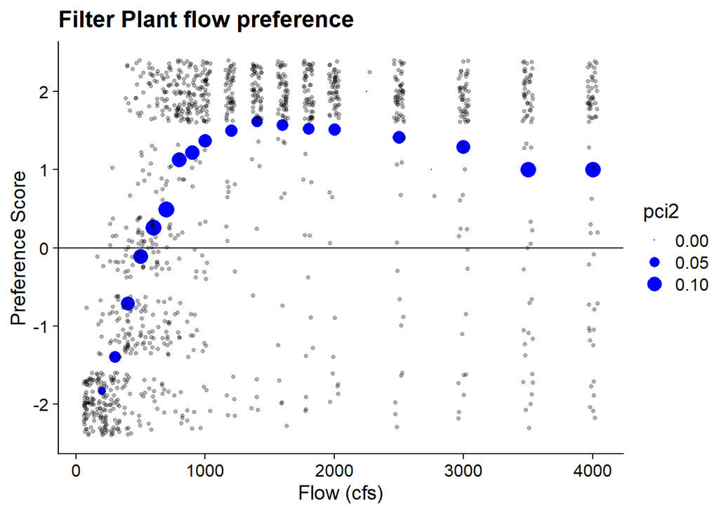

```r
p1 <- ggplot() +
  geom_point(data = results, aes(x = flow, y = pref.average, size = pci2), color = 'blue') +
  scale_size(range = c(0.1, 5)) +
  geom_jitter(data = filter(flowpref.dat, segment.name == segment_name), aes(x = as.numeric(flow), y = preference.code), size = 1, alpha = 0.3) +
  labs(x = "Flow (cfs)",
       y = "Preference Score") +
  geom_hline(yintercept = 0) +
  ggtitle("Filter Plant flow preference")

print(p1)
```